# trabajo 3: Microsimulación + Clusters

Matías Nadinic Bravo

2025-11-18

# 1. Introducción

La estructura urbana del Gran Santiago se caracteriza por una marcada segregación socioespacial que históricamente ha dividido la ciudad entre un cono de alta renta y una periferia de mayor vulnerabilidad. Comprender las dinámicas actuales de esta segregación requiere ir más allá de los indicadores tradicionales, integrando variables que midan la exclusión estructural (como el analfabetismo) y los cambios demográficos recientes (como la migración).

El principal desafío para analizar estos fenómenos a escala intra-urbana (barrio) es la falta de datos granulares. El Censo proporciona información demográfica universal (totales) pero carece de la granularidad socioeconómica necesaria para el perfilamiento. Para cerrar esta brecha, el presente trabajo recurre a la Microsimulación Espacial (Raking) para generar estimaciones fiables del analfabetismo a nivel de zona censal, basándose en la Encuesta CASEN.

El objetivo es integrar esta estimación simulada con variables reales del Censo (migración y rezago escolar) para construir una tipología de barrios. Esta tipología será analizada mediante el Clustering K-Means, y su variabilidad interna será medida mediante el Índice de Entropía de Shannon, permitiendo identificar si las comunas son socialmente homogéneas (segregadas) o heterogéneas (mezcladas).

## **1.1. Objetivo General**

Analizar la estructura socioespacial del Gran Santiago mediante la integración de datos censales y encuestas de hogares, identificando patrones de segregación y heterogeneidad territorial.

## **1.2. Objetivos Específicos**

- Estimar la tasa de analfabetismo a nivel de zona censal mediante técnicas de Microsimulación Espacial (algoritmo Iterative Proportional Fitting).
- Tipificar los territorios del Gran Santiago en perfiles socioeconómicos distintivos mediante análisis de Clúster (K-Means).
- Evaluar el grado de mezcla o segregación interna de las comunas utilizando el Índice de Entropía de Shannon.

# **2. Marco Teórico Referencial**

Para abordar la complejidad territorial, este estudio se apoya en tres pilares metodológicos y conceptuales:

## **2.1. Microsimulación Espacial (Spatial Microsimulation)**

Es una técnica estadística que permite generar una población sintética para áreas geográficas pequeñas. Se utiliza el método de Raking que re-pondera los individuos de la encuesta (CASEN) para que coincidan con los totales marginales del Censo, permitiendo estimar variables “ocultas” (como el analfabetismo detallado) en el territorio.

## **2.2. Análisis de Clúster (K-Means)**

Es un método no supervisado que agrupa objetos (zonas censales) basándose en su similitud estadística, minimizando la varianza dentro del grupo y maximizando la diferencia entre grupos, lo que permite identificar “tipologías de barrio”.

## **2.3. Índice de Entropía de Shannon (**$H$**)**

Este índice se utiliza para medir la diversidad o mezcla de los clústeres al interior de cada comuna. Un valor alto de $H$ indica una comuna heterogénea (múltiples perfiles), mientras que un valor bajo indica homogeneidad o segregación (predominio de un solo grupo social).

# **3. Metodología y Procesamiento de Datos**

## **3.1. Carga de Librerías y Configuración**

Se utilizan librerías especializadas para la manipulación espacial (sf), conexión a bases de datos (RPostgres), microsimulación (rakeR) y visualización (ggplot2).

```r
library(rakeR)       # Microsimulación
```

```r
library(RPostgres)   # Conexión BD
library(DBI)         # Manejo BD
library(sf)          # Mapas
library(dplyr)       # Datos
library(tidyr)       # Transformación de datos (para boxplots)
library(ggplot2)     # Gráficos
library(factoextra)  # Clusters
library(cluster)     # K-Means
library(stringr)     # Texto

# Semilla para resultados replicables
set.seed(123)

# Tema Gráfico Unificado
tema_pro = theme_minimal() +
  theme(
    plot.title = element_text(face="bold", size=14, hjust=0.5),
    plot.subtitle = element_text(size=10, color="grey40", hjust=0.5),
    panel.grid.major = element_line(color="grey90", linetype="dashed"),
    legend.position = "bottom"
  )
```

## **3.2. Ejecución de la Microsimulación (Raking)**

Se carga la CASEN y el Censo. Se limpian y recodifican las variables (Edad, Sexo, Escolaridad) para hacerlas compatibles con los datos marginales del Censo. La variable objetivo es el Analfabetismo.

```r
# 1.1 Carga (RUTAS CORREGIDAS PARA R MARKDOWN)

# Intenta retroceder dos niveles para encontrar la carpeta 'data'
# Si tu archivo está en "trabajos/t3", esto debería funcionar:
ruta_casen = "../../data/casen_rm.rds"
ruta_censo = "../../data/cons_censo_df.rds"

# --- DIAGNÓSTICO DE EMERGENCIA (Solo para verificar) ---
if(!file.exists(ruta_casen)) {
  # Si falla, intentamos con un solo nivel atrás (por si está en "trabajos/")
  ruta_casen = "../data/casen_rm.rds"
  ruta_censo = "../data/cons_censo_df.rds"
}

if(!file.exists(ruta_casen)) {
  # Si falla de nuevo, asumimos que 'data' está en la misma carpeta
  ruta_casen = "data/casen_rm.rds"
  ruta_censo = "data/cons_censo_df.rds"
}

# Finalmente cargamos
casen = readRDS(ruta_casen)
cons_censo_df = readRDS(ruta_censo)

# 1.2 Pre-procesamiento
col_cons = sort(setdiff(names(cons_censo_df), c("GEOCODIGO", "COMUNA")))
age_levels = grep("^edad", col_cons, value = TRUE)
esc_levels = grep("^esco", col_cons, value = TRUE)
sexo_levels = grep("^sexo", col_cons, value = TRUE)

# Selección y Limpieza CASEN
casen = casen[, c("estrato", "esc", "edad", "sexo", "e6a", "e1")]
casen$Comuna = substr(as.character(casen$estrato), 1, 5)
casen$estrato = NULL
casen$esc = as.integer(unclass(casen$esc))
casen$edad = as.integer(unclass(casen$edad))
casen$e6a = as.numeric(unclass(casen$e6a))
casen$sexo = as.integer(unclass(casen$sexo))
casen$e1 = as.numeric(unclass(casen$e1))

# Variable Analfabetismo
casen$no_lee_escribe = ifelse(is.na(casen$e1), 0, ifelse(casen$e1 == 1, 0, 1))
casen$e1 = NULL

# Imputación Escolaridad
idx_na = which(is.na(casen$esc))
fit = lm(esc ~ e6a, data = casen[-idx_na,])
pred = predict(fit, newdata = casen[idx_na, ,drop = FALSE])
casen$esc[idx_na] = as.integer(round(pmax(0, pmin(29, pred))))
casen$ID = as.character(seq_len(nrow(casen)))

# Recodificación
casen$edad_cat = cut(casen$edad, breaks = c(0,30,40,50,60,70,80,Inf), labels = age_levels, right = FALSE, include.lowest = TRUE)
casen$esc_cat = factor(with(casen, ifelse(esc == 0, esc_levels[1], ifelse(esc <= 8, esc_levels[2], ifelse(esc <= 12, esc_levels[3], esc_levels[4])))), levels = esc_levels)
casen$sexo_cat = factor(ifelse(casen$sexo == 2, sexo_levels[1], ifelse(casen$sexo == 1, sexo_levels[2], NA)), levels = sexo_levels)

# Algoritmo rakeR
cons_censo_comunas = split(cons_censo_df, cons_censo_df$COMUNA)
inds_list = split(casen, casen$Comuna)
comunas_comunes = intersect(names(cons_censo_comunas), names(inds_list))

sim_list = lapply(comunas_comunes, function(zona) {
  cons_i = cons_censo_comunas[[zona]]
  col_order = sort(setdiff(names(cons_i), c("COMUNA","GEOCODIGO")))
  cons_i = cons_i[, c("GEOCODIGO", col_order), drop = FALSE]
  tmp = inds_list[[zona]]
  inds_i = tmp[, c("ID","edad_cat","esc_cat","sexo_cat"), drop = FALSE]
  names(inds_i) = c("ID","Edad","Escolaridad","Sexo")
  w_frac = weight(cons = cons_i, inds = inds_i, vars = c("Edad","Escolaridad","Sexo"))
  sim_i  = integerise(weights = w_frac, inds = inds_i, seed = 123)
  merge(sim_i, tmp[, c("ID","no_lee_escribe")], by = "ID", all.x = TRUE)
})
sim_df = data.table::rbindlist(sim_list, idcol = "COMUNA")


## -----------------------------------------------------------------------------
## 2. CÁLCULO DE TASAS (AGREGACIÓN)
## -----------------------------------------------------------------------------
message("--- (2/8) CALCULANDO TASAS POR ZONA ---")
```

```
## --- (2/8) CALCULANDO TASAS POR ZONA ---
```

```r
df_tasas = sim_df %>%
  group_by(zone) %>%
  summarise(n_total = n(), n_no_lee = sum(no_lee_escribe, na.rm = TRUE)) %>%
  mutate(tasa_analfabetismo = n_no_lee / n_total)
df_tasas$zone = trimws(as.character(df_tasas$zone))
```

## **3.3. Integración de Datos Espaciales y Censales**

A continuación, se descargan las geometrías y variables adicionales (Migración y Rezago Escolar) directamente desde la base de datos PostgreSQL/PostGIS. Se filtra el área de estudio exclusivamente al Gran Santiago (34 comunas).

```r
con = dbConnect(RPostgres::Postgres(), dbname="censo_rm_2017", host="localhost", port=5432, user="postgres", password="postgres")

# Geometría
query_geo = "SELECT geocodigo, geom FROM dpa.zonas_censales_rm"
zonas_sf = st_read(con, query = query_geo, quiet = TRUE)
zonas_sf$geocodigo = trimws(as.character(zonas_sf$geocodigo))

# Datos Reales (Migración/Educación)
sql_indicadores = "
SELECT z.geocodigo, c.nom_comuna,
  ROUND(COUNT(*) FILTER (WHERE p.p12 NOT IN (1, 2, 98, 99)) * 100.0 / NULLIF(COUNT(*), 0), 2) AS ptje_migrantes,
  ROUND(COUNT(*) FILTER (WHERE p.p13 = 3) * 100.0 / NULLIF(COUNT(*) FILTER (WHERE p.p13 IN (1, 2, 3)), 0), 2) AS ptje_nunca_asistio
FROM public.personas p
JOIN public.hogares h ON p.hogar_ref_id = h.hogar_ref_id
JOIN public.viviendas v ON h.vivienda_ref_id = v.vivienda_ref_id
JOIN public.zonas z ON v.zonaloc_ref_id = z.zonaloc_ref_id
JOIN public.comunas c ON z.codigo_comuna = c.codigo_comuna
GROUP BY z.geocodigo, c.nom_comuna;"
df_censo_real = dbGetQuery(con, sql_indicadores)
df_censo_real$geocodigo = trimws(as.character(df_censo_real$geocodigo))

# Filtro Gran Santiago y Unión Final
comunas_gs = c("SANTIAGO", "CERRILLOS", "CERRO NAVIA", "CONCHALI", "EL BOSQUE", "ESTACION CENTRAL", "HUECHURABA", "INDEPENDENCIA", "LA CISTERNA", "LA FLORIDA", "LA GRANJA", "LA PINTANA", "LA REINA", "LAS CONDES", "LO BARNECHEA", "LO ESPEJO", "LO PRADO", "MACUL", "MAIPU", "ÑUÑOA", "PEDRO AGUIRRE CERDA", "PEÑALOLEN", "PROVIDENCIA", "PUDAHUEL", "QUILICURA", "QUINTA NORMAL", "RECOLETA", "RENCA", "SAN JOAQUIN", "SAN MIGUEL", "SAN RAMON", "VITACURA", "PUENTE ALTO", "SAN BERNARDO")

sf_master = zonas_sf %>%
  dplyr::inner_join(df_censo_real, by = "geocodigo") %>%
  dplyr::inner_join(df_tasas, by = c("geocodigo" = "zone")) %>%
  filter(trimws(nom_comuna) %in% comunas_gs) %>%
  na.omit()

# Bordes para mapas
sf_bordes = sf_master %>% group_by(nom_comuna) %>% summarise()
```

4. **Análisis de Resultados**

**4.1. Distribución del Analfabetismo (Microsimulación)**

El primer resultado relevante es la espacialización de la tasa de analfabetismo. Al ser una variable rara en entornos urbanos, su concentración indica focos de alta vulnerabilidad social.

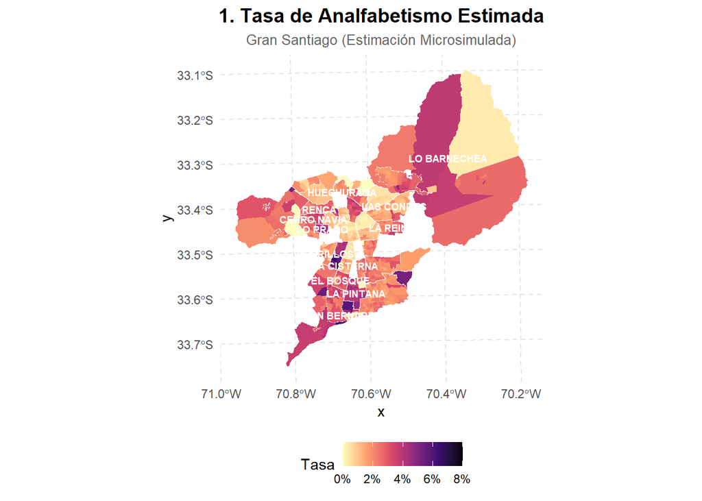

```r
mapa_1 = ggplot() +
  geom_sf(data=sf_master, aes(fill=tasa_analfabetismo), lwd=0, color=NA) +
  geom_sf(data=sf_bordes, fill=NA, color="white", lwd=0.3) +
  geom_sf_text(data=sf_bordes, aes(label=nom_comuna), size=2.5, color="white", fontface="bold", check_overlap=TRUE) +
  scale_fill_viridis_c(option="magma", direction=-1, labels=scales::percent, name="Tasa") +
  labs(title="1. Tasa de Analfabetismo Estimada", subtitle="Gran Santiago (Estimación Microsimulada)") +
  tema_pro
print(mapa_1)
```